# eSVD2: `master` (3d5f7bf) versus `devel` (1.2.0) on simulated cohorts

Drafted by Claude for Kevin Z. Lin

2026-09-29

```r
library(ggplot2)
```

```r
out_dir <- "output"
version_vec <- c("master", "devel", "devel_nocap", "devel_swap")

gene_df <- do.call(rbind, lapply(version_vec, function(v){
  utils::read.csv(file.path(out_dir, v, "genes.csv"))
}))
truth_df <- utils::read.csv(file.path(out_dir, "truth.csv"))
gene_df <- merge(gene_df, truth_df, by = c("regime", "rep", "gene"))
gene_df$p <- 10^(-gene_df$log10p)
gene_df$status <- factor(ifelse(gene_df$is_de, "DE", "null"),
                         levels = c("null", "DE"))

# The rate shares units with the fitted library size, which contains the
# gene's intercept; the generator's library averages 1. Multiplying the true
# rate by the gene's median fitted library size (stored by 1.2.0, and the same
# fit under every devel arm) puts both on the fit's scale.
library_df <- gene_df[gene_df$version == "devel",
                      c("regime", "rep", "gene", "nuisance_library_median")]
colnames(library_df)[4] <- "s_median"
gene_df <- merge(gene_df[, colnames(gene_df) != "nuisance_library_median"],
                 library_df, by = c("regime", "rep", "gene"))
gene_df$nuisance_true_fit <- gene_df$nuisance_true * gene_df$s_median

run_df <- do.call(rbind, lapply(version_vec, function(v){
  utils::read.csv(file.path(out_dir, v, "runs.csv"))
}))
corner_df <- do.call(rbind, lapply(c("master", "devel"), function(v){
  utils::read.csv(file.path(out_dir, v, "corner_cases.csv"))
}))
wall_time_df <- utils::read.csv(file.path(out_dir, "wall_time.csv"),
                                header = FALSE)

# One row per gene per data set, with the versions side by side.
.wide <- function(column){
  res <- gene_df[gene_df$version == "master",
                 c("regime", "rep", "gene", "status", column)]
  colnames(res)[5] <- "master"
  for(v in setdiff(version_vec, "master")){
    tmp_df <- gene_df[gene_df$version == v, c("regime", "rep", "gene", column)]
    colnames(tmp_df)[4] <- v
    res <- merge(res, tmp_df, by = c("regime", "rep", "gene"))
  }
  res
}

regime_levels <- c("baseline", "null", "strong_de", "near_poisson",
                   "minimal_design", "generate_null")
version_col_vec <- c(master = "#2a78d6", devel = "#eb6834",
                     devel_nocap = "#9e9d97", devel_swap = "#1baf7a")
status_col_vec <- c(null = "#9e9d97", DE = "#4a3aa7")
nuisance_status_col_vec <- c(estimated = "#2a78d6", capped = "#eb6834",
                             boundary = "#4a3aa7")

theme_set(theme_bw(base_size = 11))
theme_update(panel.grid.minor = element_blank(),
             strip.background = element_rect(fill = "#f1f0ec", colour = NA))
```

```r
num_null_genes <- sum(!gene_df$is_de & gene_df$version == "master" &
                        gene_df$regime == "null") / 10
.fp_per_rep <- function(v, r){
  idx <- gene_df$version == v & gene_df$regime == r
  sum(gene_df$fdr[idx] < 0.05 & !gene_df$is_de[idx]) / 10
}
.tp_per_rep <- function(v, r){
  idx <- gene_df$version == v & gene_df$regime == r
  sum(gene_df$fdr[idx] < 0.05 & gene_df$is_de[idx]) / 10
}
.type1 <- function(v, r){
  idx <- gene_df$version == v & gene_df$regime == r & !gene_df$is_de
  mean(gene_df$p[idx] < 0.05)
}
.within_twofold <- function(v){
  idx <- gene_df$version == v & gene_df$regime %in%
    c("baseline", "null", "strong_de", "minimal_design")
  mean(abs(log2(gene_df$nuisance[idx] / gene_df$nuisance_true_fit[idx])) <= 1)
}
logfc_wide_df <- .wide("logFC")
min_logfc_cor <- min(sapply(split(logfc_wide_df, logfc_wide_df$regime),
                            function(x){stats::cor(x$master, x$devel)}))
teststat_wide_df <- .wide("teststat")
min_teststat_cor <- min(sapply(split(teststat_wide_df, teststat_wide_df$regime),
                               function(x){stats::cor(x$master, x$devel)}))
swap_max <- max(abs(teststat_wide_df$master - teststat_wide_df$devel_swap))

devel_df <- gene_df[gene_df$version == "devel", ]
ordinary_vec <- c("baseline", "null", "strong_de", "minimal_design",
                  "generate_null")
frac_capped_vec <- sapply(ordinary_vec, function(r){
  mean(devel_df$nuisance_status[devel_df$regime == r] %in%
         c("capped", "boundary"))
})
```

# 1 Overview

This report compares two versions of `eSVD2` on the same simulated data:

- **`master`**: git commit `3d5f7bf`, `DESCRIPTION` version 1.0.1.07. This is what `devtools::install_github("linnykos/eSVD2")` installs today.
- **`devel`**: the `devel` branch at commit `1a0a536`, version 1.2.0, the candidate for CRAN. It caps each gene’s nuisance rate at 10 times the median of its library size (`cap_multiplier = 10`, the default).

A third arm, **`devel_nocap`**, is 1.2.0 run with `cap_multiplier = Inf`. Its rates are those of version 1.1.0, which is the `devel` a first edition of this report compared against master. It is kept as a reference, because it shows what the cap repairs. (Its statistics equal those of that first run to every stored digit.)

The report asks two questions. **Which behaviors got better?** And **does `devel` change what eSVD-DE reports on ordinary data, or mostly how it behaves at the edges?**

**The short answer.**

1. **The point estimate did not change.** The log2 fold changes of the two versions agree at a Pearson correlation of at least 0.9993 in every regime.
2. **Most of the fixes are corner-case fixes, and they behave as `NEWS.md` says.** Inputs that used to crash deep in the optimizer with `missing value where TRUE/FALSE needed`, or finish silently with a wrong answer, now stop at the first step with a message that names the problem (section 7).
3. **The nuisance (overdispersion) rate is estimated differently, and with the cap the test is calibrated as master’s was.**
   - *The estimate.* In the regimes where the rate can be estimated, `devel` puts 96% of genes within twofold of the true rate, against 56% for master.
   - *False discoveries.* Under the global null, 0.2 of 300 null genes per data set reach FDR < 0.05, against 0.2 under master and 2.7 without the cap.
   - *The near-Poisson regime.* The type-I error at p < 0.05 is 0.065, against 0.067 for master and 0.28 without the cap.
   - *The statistics.* The Welch statistics are close to master’s (Pearson r of at least 0.986 in every regime), and putting master’s rates into `devel` still reproduces master’s statistics, to within 0.006 (section 5.3).
   - *What the cap acts on.* It acts on 7% to 12% of genes in ordinary data.
4. **The cost is small but visible.** On the `generate_null()` cohorts `devel` finds 8.1 of 10 DE genes per data set, against 8.8 for master. Elsewhere the two are within simulation noise of each other on false and true discoveries (section 6.2).

## 1.1 How the comparison was run

The versions are installed into separate private libraries and run in separate R processes. The step-by-step API (`initialize_esvd()` through `compute_pvalue()`) has the same function names and arguments in both, except for `cap_multiplier`, which only 1.2.0 has. So one script drives every version, calling the steps in the order `eSVD()` runs them. All heavy computation happens in the scripts; this document only reads their CSVs.

| Script | What it does |
| --- | --- |
| `00_install_versions_claude.sh` | `git archive 3d5f7bf` → `lib/master`; `git archive d49e402` (1.1.0) → `lib/devel_1.1.0`, used by `../overdispersion_brainstorm/`; the working tree (1.2.0) → `lib/devel` |
| `helpers_claude.R` | the simulator and the pipeline, shared by the scripts below |
| `01_simulate_data_claude.R` | 6 regimes × 10 replicates → `data/*.rds`, and the truth → `output/truth.csv` |
| `02_run_regimes_claude.R` | fits all 60 data sets with one version or arm → `output/<label>/genes.csv`, `runs.csv` |
| `03_corner_cases_claude.R` | 12 perturbed cohorts per version → `output/<version>/corner_cases.csv` |
| `run_all_claude.sh` | all of the above, end to end |

The whole of `run_all_claude.sh` took **6.4 minutes** on the laptop it was run on.

**`devel_swap` is an ablation, not a version.** It runs the `devel` code on each data set, but right after `estimate_nuisance()` it overwrites the per-gene nuisance rate with the value `master` estimated on the same data set. Where `devel_swap` matches `master`, the nuisance estimate explains the difference between the versions.

## 1.2 The simulated regimes

Every regime has 20 individuals (10 case, 10 control), 30 cells each, and 300 genes. Except for `generate_null`, the data come from the eSVD hierarchical model itself, using the generator of `.build_tiny_data()` in `tests/testthat/helper-fixtures.R`. That model has:

- a rank-3 latent structure;
- an individual-level random effect;
- Sex and Age effects;
- a per-cell library size;
- counts $A_{ji} \sim \mathrm{Poisson}(\ell_{ji} \lambda_{ji})$ with $\lambda_{ji} \sim \mathrm{Gamma}(\text{mean} = \mu_{ji}, \text{rate} = \beta_j)$.

The truth for a gene’s log2 fold change is the ratio of the arithmetic means of $\exp(\text{natural parameter})$ in the two arms. That is what both the logFC and the Welch statistic contrast.

| Regime | DE genes | Nuisance rate $\beta_j$ | What it probes |
| --- | --- | --- | --- |
| `baseline` | 15, effect 0.8 (natural log) | U(2, 8) on the log scale | ordinary data |
| `null` | 0 | U(2, 8) | calibration |
| `strong_de` | 15, effect ±3 | U(2, 8) | large Welch statistics; the t → z mapping |
| `near_poisson` | 15, effect 0.8 | U(50, 1000) | little overdispersion; where the cap binds for almost every gene |
| `minimal_design` | 15, effect 0.8 | U(2, 8) | no Sex/Age, so covariates are only Intercept + Log_UMI + CC (the GLM-fallback offset fix) |
| `generate_null` | 10 | the package’s own `generate_null()` | a generator not written for this report |

Each regime has 10 replicates with different seeds. The fit uses `k = 3`, `l2pen = 0.1`, `max_iter = 50`, and otherwise the package defaults.

# 2 What changed, according to `NEWS.md`

| Change in `devel` | Version | Where this report looks at it |
| --- | --- | --- |
| Welch → Gaussian mapping done on the log scale, so a large statistic no longer becomes `Inf` | 1.0.2 | 6.4 |
| `multtest()` reports its empirical-null estimator and warns on the `locfdr` fallback; Efron’s truncated MLE regains `p0 <= 1` | 1.0.2 | 6.5, 7 |
| `gamma_rate` no longer caps its search at the largest library size | 1.0.2 | 4, 5, 6 |
| `initialize_esvd()` refuses all-zero genes; zeroes `NA` in sparse input | 1.0.2 | 7 |
| GLM fallback (≤ 1 covariate besides intercept and offsets) keeps the library-size offset | 1.0.2 | 3, regime `minimal_design` |
| Collinear covariates refused by name | 1.0.2 | 7 |
| `eSVD()` refuses individuals in both arms, one-individual arms, and individuals with too few cells | 1.0.2 | 7 |
| Iterative SVD starts from a fixed vector (determinism) | 1.0.2 | 7 |
| New: `log2fc_vec`, `log2fc_se_vec`, `compute_log_fold_change()` | 1.1.0 | 8 |
| **The nuisance rate is capped at `cap_multiplier` (10) times the gene’s median library size; a per-gene `nuisance_status`** | 1.2.0 | 4, 6, 8 |
| New: `recompute_pvalue()`, `plot_nuisance()`, `plot_fitted_vs_observed()` | 1.2.0 | not exercised here (they need `eSVD()`’s object; see the tests) |

# 3 Point estimates: the log2 fold change

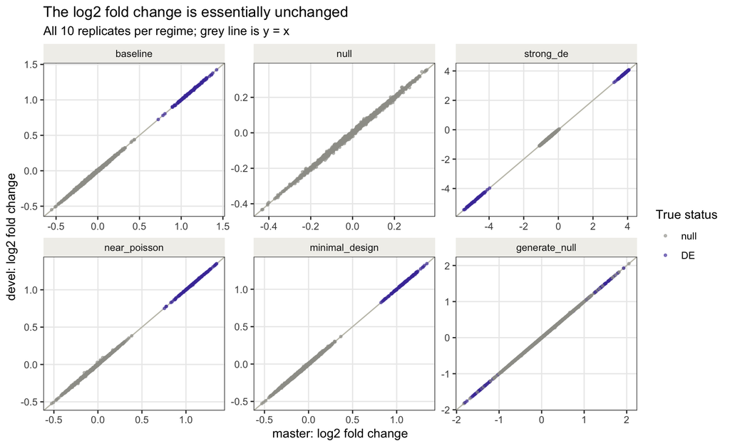

```r
plot_df <- logfc_wide_df
plot_df$regime <- factor(plot_df$regime, levels = regime_levels)
plot1 <- ggplot2::ggplot(plot_df, ggplot2::aes(x = master, y = devel))
plot1 <- plot1 + ggplot2::geom_abline(slope = 1, intercept = 0,
                                      colour = "#c3c2b7", linewidth = 0.5)
plot1 <- plot1 + ggplot2::geom_point(ggplot2::aes(colour = status),
                                     size = 0.8, alpha = 0.6)
plot1 <- plot1 + ggplot2::facet_wrap(~ regime, nrow = 2, scales = "free")
plot1 <- plot1 + ggplot2::scale_colour_manual(values = status_col_vec,
                                              name = "True status")
plot1 <- plot1 + ggplot2::labs(x = "master: log2 fold change",
                               y = "devel: log2 fold change",
                               title = "The log2 fold change is essentially unchanged",
                               subtitle = "All 10 replicates per regime; grey line is y = x")
plot(plot1)
```

```r
agreement_df <- do.call(rbind, lapply(regime_levels, function(r){
  x <- logfc_wide_df[logfc_wide_df$regime == r, ]
  data.frame(regime = r,
             pearson = stats::cor(x$master, x$devel),
             median_abs_diff = stats::median(abs(x$master - x$devel)),
             max_abs_diff = max(abs(x$master - x$devel)))
}))
knitr::kable(agreement_df, digits = 4,
             col.names = c("Regime", "Pearson r", "Median |Δ|", "Max |Δ|"),
             caption = "log2 fold change, master vs devel, all genes and replicates.")
```

log2 fold change, master vs devel, all genes and replicates.

| Regime | Pearson r | Median \|Δ\| | Max \|Δ\| |
| --- | --- | --- | --- |
| baseline | 0.9999 | 0.0018 | 0.0256 |
| null | 0.9993 | 0.0019 | 0.0243 |
| strong_de | 1.0000 | 0.0019 | 0.0683 |
| near_poisson | 0.9999 | 0.0008 | 0.0437 |
| minimal_design | 0.9999 | 0.0014 | 0.0250 |
| generate_null | 1.0000 | 0.0001 | 0.0367 |

The logFC is `log2(case_mean / control_mean)`, where each mean averages the per-individual posterior means. The posterior mean moves only a little with the nuisance rate, so this estimate is nearly identical across versions. The small differences come from the fit and from the rescaling by `bool_stabilize_underdispersion`. `devel` returns this quantity directly as `log2fc_vec`; for `master` it is computed from `case_mean` and `control_mean`. The two definitions are the same.

**`minimal_design` is where the GLM-fallback offset fix would show, and it does not.** With only Intercept + Log_UMI + CC, `master` fitted the intercepts without the depth offset. That changes the initialization, but after two rounds of `opt_esvd()` the fold changes agree as closely as in any other regime.

# 4 The nuisance (overdispersion) estimate

`nuisance_vec` is the Gamma **rate** $\beta_j = 1/\gamma_j$: a large value means little overdispersion, and $\beta_j \to \infty$ is a Poisson gene.

The three versions compute it as follows:

- **`master`**: `gamma_rate` searched only up to the gene’s largest library size, so its rate is `min(MLE, max_i s_ji)`.
- **`devel_nocap`** (1.1.0’s rate): the maximum-likelihood estimate itself.
- **`devel`** (1.2.0): `max(min(MLE, 10 · m_j), 1e-4 · m_j)`, with `m_j = median_i s_ji`. A gene with no finite MLE is set to the cap.

`../OVERDISPERSION_BRAINSTORM.md` explains why the cap was chosen, and `../overdispersion_brainstorm/overdispersion_cap_claude.html` explains it with formulas and plots.

> **The units trap.** The rate shares its units with the fitted library size `s_ji`, which contains the gene’s intercept. The simulator’s library size averages 1. So the simulator’s rate is not on the fit’s scale. The first edition of this report compared the two directly and concluded that the uncapped estimate was “biased upward two- to threefold”. Most of that was the units. Below, the true rate is multiplied by the gene’s median fitted library size before the comparison.

## 4.1 Against the truth

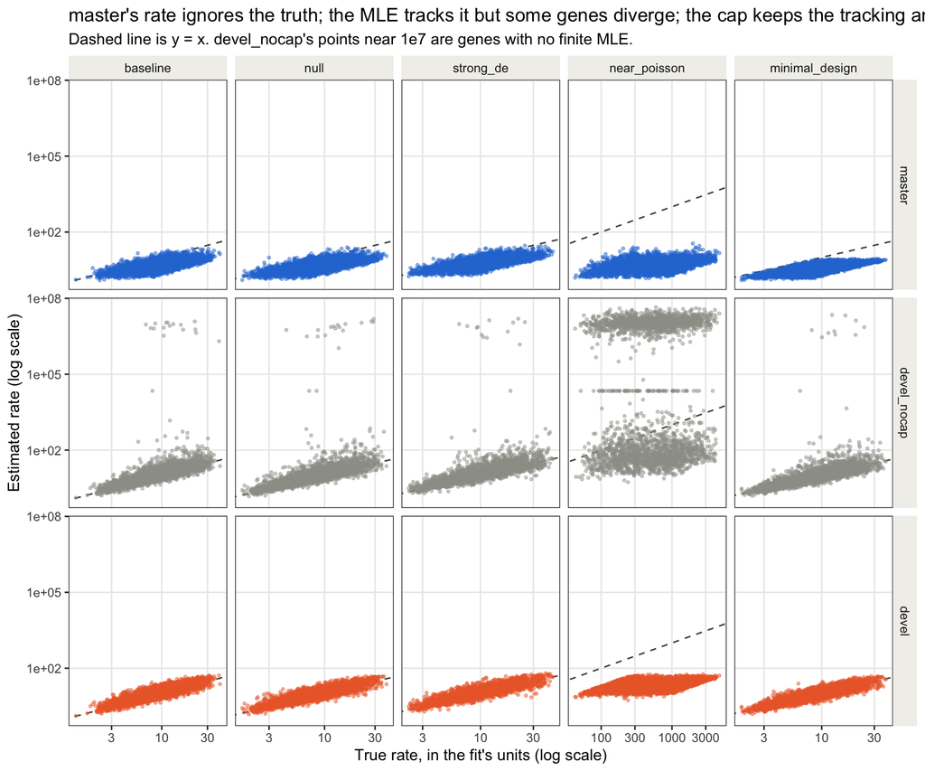

```r
plot_df <- gene_df[gene_df$version %in% c("master", "devel_nocap", "devel") &
                     gene_df$regime != "generate_null", ]
plot_df$regime <- factor(plot_df$regime, levels = regime_levels)
plot_df$version <- factor(plot_df$version,
                          levels = c("master", "devel_nocap", "devel"))
plot1 <- ggplot2::ggplot(plot_df, ggplot2::aes(x = nuisance_true_fit,
                                               y = nuisance))
plot1 <- plot1 + ggplot2::geom_abline(slope = 1, intercept = 0,
                                      colour = "#52514e", linewidth = 0.5,
                                      linetype = "dashed")
plot1 <- plot1 + ggplot2::geom_point(ggplot2::aes(colour = version),
                                     size = 0.7, alpha = 0.45)
plot1 <- plot1 + ggplot2::facet_grid(version ~ regime, scales = "free_x")
plot1 <- plot1 + ggplot2::scale_x_log10()
plot1 <- plot1 + ggplot2::scale_y_log10()
plot1 <- plot1 + ggplot2::scale_colour_manual(values = version_col_vec,
                                              guide = "none")
plot1 <- plot1 + ggplot2::labs(x = "True rate, in the fit's units (log scale)",
                               y = "Estimated rate (log scale)",
                               title = "master's rate ignores the truth; the MLE tracks it but some genes diverge; the cap keeps the tracking and removes the divergence",
                               subtitle = "Dashed line is y = x. devel_nocap's points near 1e7 are genes with no finite MLE.")
plot(plot1)
```

```r
nuisance_acc_df <- do.call(rbind, lapply(setdiff(regime_levels, "generate_null"),
                                         function(r){
  do.call(rbind, lapply(c("master", "devel_nocap", "devel"), function(v){
    x <- gene_df[gene_df$regime == r & gene_df$version == v, ]
    ratio_vec <- x$nuisance / x$nuisance_true_fit
    data.frame(regime = r,
               version = v,
               spearman = stats::cor(x$nuisance, x$nuisance_true,
                                     method = "spearman"),
               median_ratio = stats::median(ratio_vec),
               within_twofold = mean(abs(log2(ratio_vec)) <= 1),
               frac_diverged = mean(x$nuisance > 1e4))
  }))
}))
knitr::kable(nuisance_acc_df, digits = c(0, 0, 2, 2, 2, 3),
             col.names = c("Regime", "Version", "Spearman with truth",
                           "Median estimate / truth", "Within twofold",
                           "Fraction > 1e4"),
             caption = "Nuisance rate against the truth in the fit's units, all genes and replicates.")
```

Nuisance rate against the truth in the fit’s units, all genes and replicates.

| Regime | Version | Spearman with truth | Median estimate / truth | Within twofold | Fraction > 1e4 |
| --- | --- | --- | --- | --- | --- |
| baseline | master | 0.03 | 0.57 | 0.59 | 0.000 |
| baseline | devel_nocap | 0.59 | 1.13 | 0.89 | 0.006 |
| baseline | devel | 0.57 | 1.13 | 0.95 | 0.000 |
| null | master | 0.05 | 0.57 | 0.60 | 0.000 |
| null | devel_nocap | 0.60 | 1.14 | 0.89 | 0.006 |
| null | devel | 0.58 | 1.14 | 0.96 | 0.000 |
| strong_de | master | 0.03 | 0.65 | 0.68 | 0.000 |
| strong_de | devel_nocap | 0.57 | 1.16 | 0.88 | 0.005 |
| strong_de | devel | 0.54 | 1.16 | 0.95 | 0.000 |
| near_poisson | master | 0.00 | 0.01 | 0.00 | 0.000 |
| near_poisson | devel_nocap | 0.08 | 2.08 | 0.07 | 0.481 |
| near_poisson | devel | 0.01 | 0.04 | 0.00 | 0.000 |
| minimal_design | master | -0.01 | 0.41 | 0.36 | 0.000 |
| minimal_design | devel_nocap | 0.61 | 1.04 | 0.92 | 0.004 |
| minimal_design | devel | 0.60 | 1.04 | 0.97 | 0.000 |

```r
status_df <- do.call(rbind, lapply(regime_levels, function(r){
  x <- devel_df[devel_df$regime == r, ]
  data.frame(regime = r,
             estimated = mean(x$nuisance_status == "estimated"),
             capped = mean(x$nuisance_status == "capped"),
             boundary = mean(x$nuisance_status == "boundary"),
             failed = mean(x$nuisance_status == "failed"),
             median_library = stats::median(x$s_median))
}))
knitr::kable(status_df, digits = 3,
             col.names = c("Regime", "estimated", "capped", "boundary",
                           "failed", "Median of m_j"),
             caption = "devel: share of genes by nuisance_status, all genes and replicates. The cap is 10 times m_j.")
```

devel: share of genes by nuisance_status, all genes and replicates. The cap is 10 times m_j.

| Regime | estimated | capped | boundary | failed | Median of m_j |
| --- | --- | --- | --- | --- | --- |
| baseline | 0.886 | 0.109 | 0.006 | 0 | 2.107 |
| null | 0.885 | 0.109 | 0.006 | 0 | 2.060 |
| strong_de | 0.882 | 0.113 | 0.005 | 0 | 2.491 |
| near_poisson | 0.045 | 0.474 | 0.481 | 0 | 2.156 |
| minimal_design | 0.908 | 0.088 | 0.004 | 0 | 2.175 |
| generate_null | 0.928 | 0.064 | 0.008 | 0 | 0.778 |

What the plot and tables show:

- **`master`’s estimates are nearly independent of the truth** (Spearman near 0). Its rate is `min(MLE, max_i s_ji)`, and in these regimes nearly every gene sits at that bound (78% to 100%, `../OVERDISPERSION_BRAINSTORM.md` section 2.1). What master reports is close to the largest library size of the gene, not a property of its overdispersion. In `near_poisson`, where the true rates are far above any library size, it is two orders of magnitude too small.
- **The MLE (`devel_nocap`) is accurate where a finite estimate exists**: its median ratio to the truth is 1.04 to 1.16 in the four ordinary regimes. But a few genes per data set have no finite MLE and run to about 1e7, and in `near_poisson` about half of them do.
- **The cap keeps the MLE’s accuracy and removes the divergence.** In the ordinary regimes it acts on about a tenth of the genes, and it raises the share within twofold of the truth from about 89% to about 95%. In `near_poisson` no version recovers the rate: those genes are close to Poisson, the likelihood is flat, and every estimate is a bound.

## 4.2 Why the nuisance matters downstream

The posterior shrinks each cell’s observed count toward the fitted mean, with a weight governed by $\beta_j$. A huge $\beta_j$ makes the posterior collapse onto the fitted mean. The within-individual posterior variance then vanishes, the denominator of the Welch statistic shrinks, and the statistic grows. The cap bounds how far that collapse can go.

# 5 Test statistics and p-values

## 5.1 Welch statistic, master vs devel

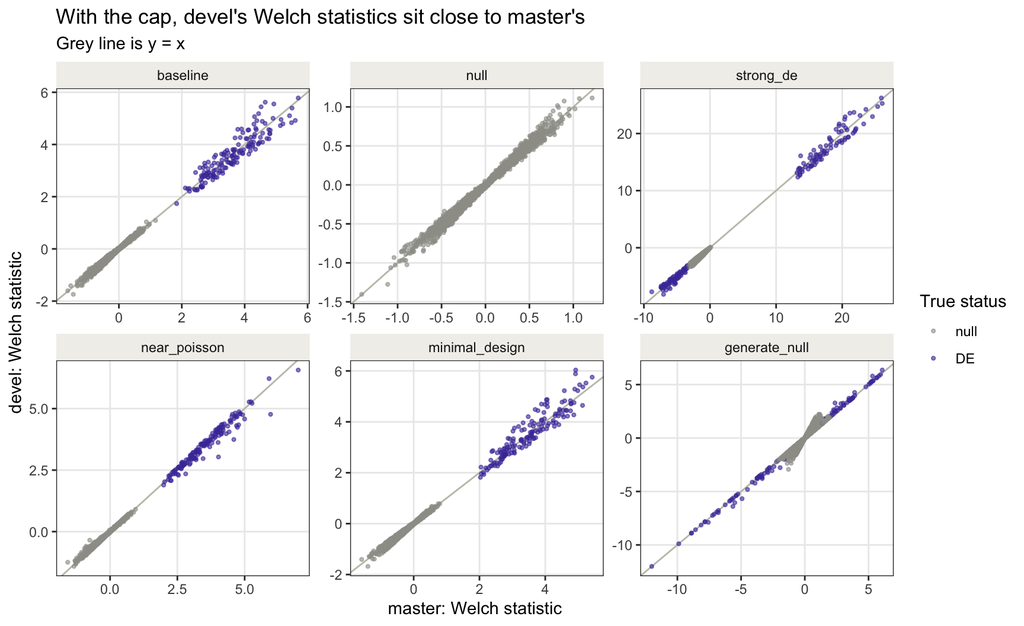

```r
plot_df <- teststat_wide_df
plot_df$regime <- factor(plot_df$regime, levels = regime_levels)
plot1 <- ggplot2::ggplot(plot_df, ggplot2::aes(x = master, y = devel))
plot1 <- plot1 + ggplot2::geom_abline(slope = 1, intercept = 0,
                                      colour = "#c3c2b7", linewidth = 0.5)
plot1 <- plot1 + ggplot2::geom_point(ggplot2::aes(colour = status),
                                     size = 0.8, alpha = 0.6)
plot1 <- plot1 + ggplot2::facet_wrap(~ regime, nrow = 2, scales = "free")
plot1 <- plot1 + ggplot2::scale_colour_manual(values = status_col_vec,
                                              name = "True status")
plot1 <- plot1 + ggplot2::labs(x = "master: Welch statistic",
                               y = "devel: Welch statistic",
                               title = "With the cap, devel's Welch statistics sit close to master's",
                               subtitle = "Grey line is y = x")
plot(plot1)
```

## 5.2 −log10 p-value, master vs devel

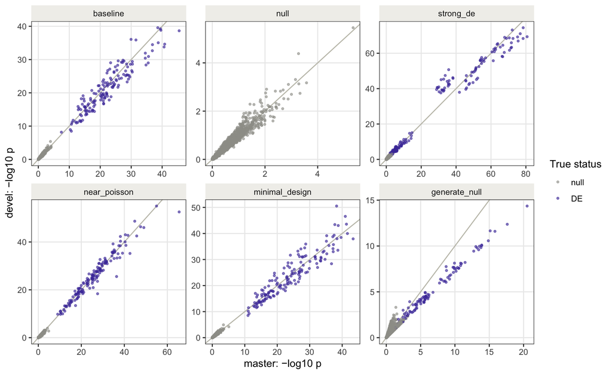

```r
plot_df <- .wide("log10p")
plot_df$regime <- factor(plot_df$regime, levels = regime_levels)
plot1 <- ggplot2::ggplot(plot_df, ggplot2::aes(x = master, y = devel))
plot1 <- plot1 + ggplot2::geom_abline(slope = 1, intercept = 0,
                                      colour = "#c3c2b7", linewidth = 0.5)
plot1 <- plot1 + ggplot2::geom_point(ggplot2::aes(colour = status),
                                     size = 0.8, alpha = 0.6)
plot1 <- plot1 + ggplot2::facet_wrap(~ regime, nrow = 2, scales = "free")
plot1 <- plot1 + ggplot2::scale_colour_manual(values = status_col_vec,
                                              name = "True status")
plot1 <- plot1 + ggplot2::labs(x = "master: −log10 p", y = "devel: −log10 p")
plot(plot1)
```

```r
log10p_wide_df <- .wide("log10p")
stat_agree_df <- do.call(rbind, lapply(regime_levels, function(r){
  x <- teststat_wide_df[teststat_wide_df$regime == r, ]
  y <- log10p_wide_df[log10p_wide_df$regime == r, ]
  data.frame(regime = r,
             teststat_cor = stats::cor(x$master, x$devel),
             teststat_median = stats::median(abs(x$master - x$devel)),
             nocap_cor = stats::cor(x$master, x$devel_nocap),
             swap_max = max(abs(x$master - x$devel_swap)),
             log10p_spearman = stats::cor(y$master, y$devel,
                                          method = "spearman"))
}))
knitr::kable(stat_agree_df, digits = 4,
             col.names = c("Regime", "Welch r (master, devel)",
                           "Median |Δ| (master, devel)",
                           "Welch r (master, devel_nocap)",
                           "Max |Δ| (master, devel_swap)",
                           "−log10 p Spearman (master, devel)"),
             caption = "Agreement of test statistics; all genes and replicates.")
```

Agreement of test statistics; all genes and replicates.

| Regime | Welch r (master, devel) | Median \|Δ\| (master, devel) | Welch r (master, devel_nocap) | Max \|Δ\| (master, devel_swap) | −log10 p Spearman (master, devel) |
| --- | --- | --- | --- | --- | --- |
| baseline | 0.9959 | 0.0147 | 0.8137 | 0.0000 | 0.9884 |
| null | 0.9951 | 0.0128 | 0.7152 | 0.0000 | 0.9884 |
| strong_de | 0.9976 | 0.0800 | 0.8114 | 0.0000 | 0.9121 |
| near_poisson | 0.9982 | 0.0077 | 0.6959 | 0.0000 | 0.9937 |
| minimal_design | 0.9960 | 0.0158 | 0.9183 | 0.0036 | 0.9856 |
| generate_null | 0.9858 | 0.0002 | 0.4455 | 0.0060 | 0.9521 |

**With the cap, `devel`’s statistics are closer to `master`’s than the uncapped ones were.** The correlation with master rises from the fourth column (`devel_nocap`) to the second (`devel`) in every regime, and the typical gene moves by a few hundredths.

## 5.3 The ablation: the nuisance estimate is the whole difference

**Put `master`’s nuisance rates into the `devel` code and the Welch statistics match `master`’s in every regime**, to within 0.006, and to all six stored digits in most regimes. The other changes between the versions move nothing that reaches the statistic in these regimes:

- the reparameterization by QR;
- the offset in the GLM fallback;
- the deterministic SVD start;
- the rewritten empirical-null estimators.

What remains between `master` and `devel` is therefore the difference between two bounds on the rate: master’s `max_i s_ji`, which most genes sit at, and `devel`’s `10 · median_i s_ji`, which about a tenth of them sit at.

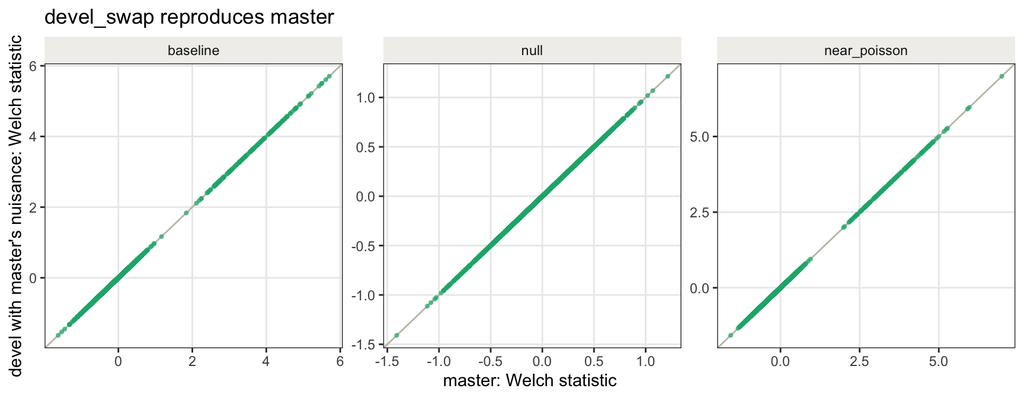

```r
plot_df <- teststat_wide_df[teststat_wide_df$regime %in%
                              c("baseline", "null", "near_poisson"), ]
plot_df$regime <- factor(plot_df$regime, levels = regime_levels)
plot1 <- ggplot2::ggplot(plot_df, ggplot2::aes(x = master, y = devel_swap))
plot1 <- plot1 + ggplot2::geom_abline(slope = 1, intercept = 0,
                                      colour = "#c3c2b7", linewidth = 0.5)
plot1 <- plot1 + ggplot2::geom_point(colour = version_col_vec[["devel_swap"]],
                                     size = 0.8, alpha = 0.6)
plot1 <- plot1 + ggplot2::facet_wrap(~ regime, nrow = 1, scales = "free")
plot1 <- plot1 + ggplot2::labs(x = "master: Welch statistic",
                               y = "devel with master's nuisance: Welch statistic",
                               title = "devel_swap reproduces master")
plot(plot1)
```

# 6 Calibration and power

## 6.1 Null genes: p-value QQ plots

The p-values below are the ones each version reports, measured against its estimated empirical null. Each panel pools the null genes of all 10 replicates.

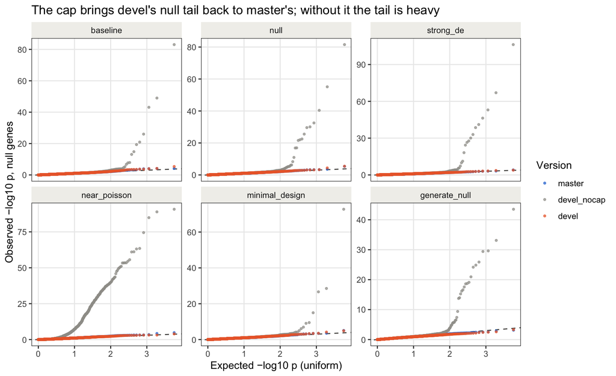

```r
qq_list <- list()
for(r in regime_levels){
  for(v in c("master", "devel_nocap", "devel")){
    p_vec <- gene_df$p[gene_df$regime == r & gene_df$version == v &
                         !gene_df$is_de]
    p_vec <- sort(p_vec)
    qq_list[[paste(r, v)]] <- data.frame(regime = r,
                                         version = v,
                                         expected = -log10(stats::ppoints(length(p_vec))),
                                         observed = -log10(p_vec))
  }
}
qq_df <- do.call(rbind, qq_list)
qq_df$regime <- factor(qq_df$regime, levels = regime_levels)
qq_df$version <- factor(qq_df$version,
                        levels = c("master", "devel_nocap", "devel"))
plot1 <- ggplot2::ggplot(qq_df, ggplot2::aes(x = expected, y = observed))
plot1 <- plot1 + ggplot2::geom_abline(slope = 1, intercept = 0,
                                      colour = "#52514e", linewidth = 0.5,
                                      linetype = "dashed")
plot1 <- plot1 + ggplot2::geom_point(ggplot2::aes(colour = version),
                                     size = 0.8, alpha = 0.7)
plot1 <- plot1 + ggplot2::facet_wrap(~ regime, nrow = 2, scales = "free_y")
plot1 <- plot1 + ggplot2::scale_colour_manual(values = version_col_vec,
                                              name = "Version")
plot1 <- plot1 + ggplot2::labs(x = "Expected −log10 p (uniform)",
                               y = "Observed −log10 p, null genes",
                               title = "The cap brings devel's null tail back to master's; without it the tail is heavy")
plot(plot1)
```

## 6.2 False and true discoveries at FDR < 0.05

```r
discovery_df <- do.call(rbind, lapply(regime_levels, function(r){
  do.call(rbind, lapply(version_vec, function(v){
    x <- gene_df[gene_df$regime == r & gene_df$version == v, ]
    sig_vec <- x$fdr < 0.05
    data.frame(regime = r,
               version = v,
               type1 = mean(x$p[!x$is_de] < 0.05),
               fp = sum(sig_vec & !x$is_de) / 10,
               tp = sum(sig_vec & x$is_de) / 10,
               num_de = sum(x$is_de) / 10,
               fdp = sum(sig_vec & !x$is_de) / max(1, sum(sig_vec)))
  }))
}))
knitr::kable(discovery_df, digits = c(0, 0, 3, 1, 1, 0, 3),
             col.names = c("Regime", "Version", "Type-I at p < 0.05",
                           "False discoveries / data set",
                           "True discoveries / data set", "DE genes",
                           "Pooled FDP"),
             caption = "Discoveries at FDR < 0.05 (BH on the empirical-null p-values), averaged over 10 replicates of 300 genes.")
```

Discoveries at FDR < 0.05 (BH on the empirical-null p-values), averaged over 10 replicates of 300 genes.

| Regime | Version | Type-I at p < 0.05 | False discoveries / data set | True discoveries / data set | DE genes | Pooled FDP |
| --- | --- | --- | --- | --- | --- | --- |
| baseline | master | 0.054 | 1.8 | 15.0 | 15 | 0.107 |
| baseline | devel | 0.052 | 2.1 | 15.0 | 15 | 0.123 |
| baseline | devel_nocap | 0.055 | 3.8 | 15.0 | 15 | 0.202 |
| baseline | devel_swap | 0.054 | 1.8 | 15.0 | 15 | 0.107 |
| null | master | 0.048 | 0.2 | 0.0 | 0 | 1.000 |
| null | devel | 0.053 | 0.2 | 0.0 | 0 | 1.000 |
| null | devel_nocap | 0.062 | 2.7 | 0.0 | 0 | 1.000 |
| null | devel_swap | 0.048 | 0.2 | 0.0 | 0 | 1.000 |
| strong_de | master | 0.042 | 0.7 | 14.5 | 15 | 0.046 |
| strong_de | devel | 0.044 | 1.1 | 14.7 | 15 | 0.070 |
| strong_de | devel_nocap | 0.051 | 3.7 | 14.6 | 15 | 0.202 |
| strong_de | devel_swap | 0.044 | 0.7 | 14.6 | 15 | 0.046 |
| near_poisson | master | 0.067 | 2.6 | 15.0 | 15 | 0.148 |
| near_poisson | devel | 0.065 | 1.8 | 15.0 | 15 | 0.107 |
| near_poisson | devel_nocap | 0.276 | 63.3 | 12.7 | 15 | 0.833 |
| near_poisson | devel_swap | 0.067 | 2.6 | 15.0 | 15 | 0.148 |
| minimal_design | master | 0.047 | 1.3 | 15.0 | 15 | 0.080 |
| minimal_design | devel | 0.051 | 1.6 | 15.0 | 15 | 0.096 |
| minimal_design | devel_nocap | 0.055 | 3.0 | 15.0 | 15 | 0.167 |
| minimal_design | devel_swap | 0.048 | 1.3 | 15.0 | 15 | 0.080 |
| generate_null | master | 0.039 | 0.2 | 8.8 | 10 | 0.022 |
| generate_null | devel | 0.034 | 0.1 | 8.1 | 10 | 0.012 |
| generate_null | devel_nocap | 0.053 | 3.8 | 8.2 | 10 | 0.317 |
| generate_null | devel_swap | 0.039 | 0.2 | 8.8 | 10 | 0.022 |

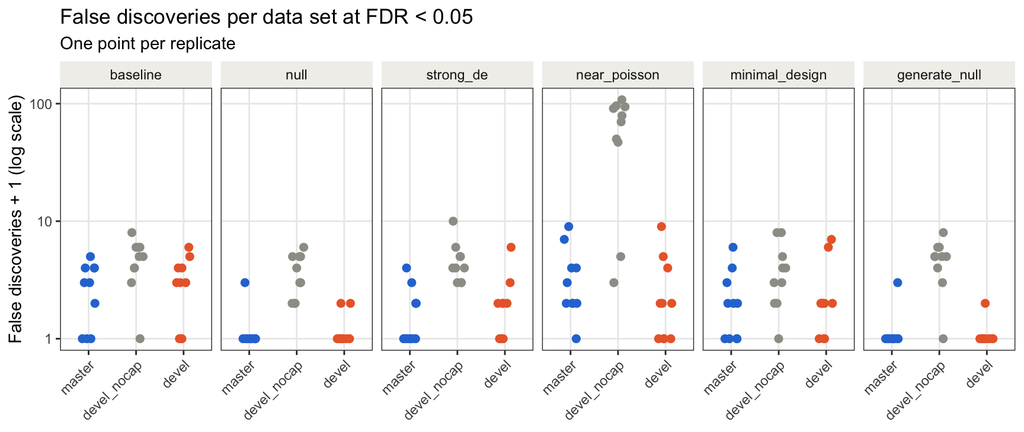

```r
fp_list <- list()
for(r in regime_levels){
  for(v in c("master", "devel_nocap", "devel")){
    for(i in 1:10){
      idx <- gene_df$regime == r & gene_df$version == v & gene_df$rep == i
      fp_list[[paste(r, v, i)]] <- data.frame(regime = r,
                                              version = v,
                                              rep = i,
                                              fp = sum(gene_df$fdr[idx] < 0.05 &
                                                         !gene_df$is_de[idx]))
    }
  }
}
fp_df <- do.call(rbind, fp_list)
fp_df$regime <- factor(fp_df$regime, levels = regime_levels)
fp_df$version <- factor(fp_df$version,
                        levels = c("master", "devel_nocap", "devel"))
plot1 <- ggplot2::ggplot(fp_df, ggplot2::aes(x = version, y = fp + 1))
plot1 <- plot1 + ggplot2::geom_point(ggplot2::aes(colour = version),
                                     position = ggplot2::position_jitter(width = 0.15,
                                                                         height = 0,
                                                                         seed = 1),
                                     size = 2)
plot1 <- plot1 + ggplot2::facet_wrap(~ regime, nrow = 1)
plot1 <- plot1 + ggplot2::scale_y_log10()
plot1 <- plot1 + ggplot2::scale_colour_manual(values = version_col_vec,
                                              guide = "none")
plot1 <- plot1 + ggplot2::theme(axis.text.x = ggplot2::element_text(angle = 45,
                                                                    hjust = 1))
plot1 <- plot1 + ggplot2::labs(x = NULL,
                               y = "False discoveries + 1 (log scale)",
                               title = "False discoveries per data set at FDR < 0.05",
                               subtitle = "One point per replicate")
plot(plot1)
```

What this shows:

- **At p < 0.05 the null genes are calibrated in `devel` and `master` in every regime** (type-I error 0.03 to 0.07). Without the cap, `near_poisson` was at 0.28.
- **In the far tail, where FDR control acts, `devel` and `master` are within simulation noise of each other.**
  - `devel` has slightly more false discoveries in `baseline`, `minimal_design` and `strong_de` (0.3 to 0.4 more per data set).
  - It has slightly fewer in `near_poisson` and `generate_null`.
  - The standard error of these per-data-set counts is about 0.5, so none of the differences is resolved.
  - Without the cap, false discoveries were 2 to 19 times master’s in five regimes, and 63 per data set (24 times master’s) in `near_poisson`.
- **Power is the same except on `generate_null()`**, where `devel` finds 8.1 of 10 DE genes against master’s 8.8. Without the cap it found 8.2. So the loss comes from estimating the rate rather than capping it at master’s bound, not from the cap itself.
- **`master` is not “right” in the sense of estimating anything.** Its rates ignore the truth (section 4.1). Treating every gene as moderately overdispersed happens to be conservative, and the cap reaches the same calibration while letting nine genes in ten keep their own estimate.

## 6.3 Where devel’s false discoveries come from

The table splits the null genes of `devel` by their `nuisance_status`, and the null genes of `devel_nocap` by whether their rate diverged.

```r
nocap_df <- gene_df[gene_df$version == "devel_nocap", ]
status_fp_df <- do.call(rbind, lapply(regime_levels, function(r){
  x <- devel_df[devel_df$regime == r & !devel_df$is_de, ]
  y <- nocap_df[nocap_df$regime == r & !nocap_df$is_de, ]
  .rate <- function(z, idx){
    if(!any(idx)) return(NA)
    mean(z$fdr[idx] < 0.05)
  }
  data.frame(regime = r,
             fp_estimated = .rate(x, x$nuisance_status == "estimated"),
             fp_capped = .rate(x, x$nuisance_status == "capped"),
             fp_boundary = .rate(x, x$nuisance_status == "boundary"),
             fp_nocap_diverged = .rate(y, y$nuisance > 1e4),
             fp_nocap_other = .rate(y, y$nuisance <= 1e4))
}))
knitr::kable(status_fp_df, digits = 3,
             col.names = c("Regime", "devel: estimated", "devel: capped",
                           "devel: boundary", "devel_nocap: rate > 1e4",
                           "devel_nocap: others"),
             caption = "Share of null genes at FDR < 0.05, by the status of their nuisance rate.")
```

Share of null genes at FDR < 0.05, by the status of their nuisance rate.

| Regime | devel: estimated | devel: capped | devel: boundary | devel_nocap: rate > 1e4 | devel_nocap: others |
| --- | --- | --- | --- | --- | --- |
| baseline | 0.006 | 0.016 | 0.000 | 0.867 | 0.009 |
| null | 0.001 | 0.000 | 0.000 | 0.737 | 0.004 |
| strong_de | 0.002 | 0.018 | 0.000 | 1.000 | 0.009 |
| near_poisson | 0.016 | 0.002 | 0.009 | 0.459 | 0.000 |
| minimal_design | 0.005 | 0.012 | 0.000 | 0.800 | 0.008 |
| generate_null | 0.000 | 0.005 | 0.000 | 0.800 | 0.006 |

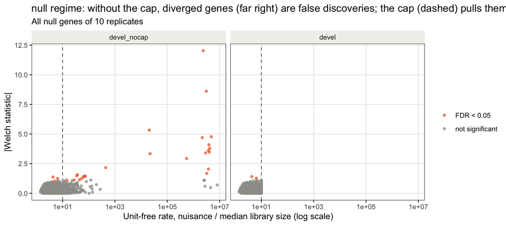

```r
plot_df <- gene_df[gene_df$version %in% c("devel_nocap", "devel") &
                     gene_df$regime == "null", ]
plot_df$version <- factor(plot_df$version, levels = c("devel_nocap", "devel"))
plot_df$discovery <- ifelse(plot_df$fdr < 0.05, "FDR < 0.05", "not significant")
plot1 <- ggplot2::ggplot(plot_df, ggplot2::aes(x = nuisance / s_median,
                                               y = abs(teststat)))
plot1 <- plot1 + ggplot2::geom_vline(xintercept = 10, colour = "#52514e",
                                     linetype = "dashed", linewidth = 0.4)
plot1 <- plot1 + ggplot2::geom_point(ggplot2::aes(colour = discovery),
                                     size = 1.2, alpha = 0.7)
plot1 <- plot1 + ggplot2::facet_wrap(~ version, nrow = 1)
plot1 <- plot1 + ggplot2::scale_x_log10()
plot1 <- plot1 + ggplot2::scale_colour_manual(values = c(`FDR < 0.05` = "#eb6834",
                                                         `not significant` = "#9e9d97"),
                                              name = NULL)
plot1 <- plot1 + ggplot2::labs(x = "Unit-free rate, nuisance / median library size (log scale)",
                               y = "|Welch statistic|",
                               title = "null regime: without the cap, diverged genes (far right) are false discoveries; the cap (dashed) pulls them in",
                               subtitle = "All null genes of 10 replicates")
plot(plot1)
```

- **Without the cap, a diverged rate was close to a guaranteed false discovery** in the ordinary regimes. Each such gene was almost always an error.
- **With the cap, no boundary gene is a false discovery in the ordinary regimes.** The false discoveries that remain are spread over estimated and capped genes, at under 2% of null genes of either status. Capped genes carry a somewhat higher share than estimated ones: they are the genes nearest the bound, and the bound still gives them less posterior variance than most.

## 6.4 The t → z mapping (`NEWS`: “no longer produces an infinite statistic”)

`master` computed the Gaussian statistic as `qnorm(pt(T, df))`, which returns `Inf` once `pt()` rounds to 1. `devel` works on the log scale. Applying the old mapping to each arm’s statistics shows where it would have failed:

```r
tz_df <- do.call(rbind, lapply(c("master", "devel_nocap", "devel"), function(v){
  x <- gene_df[gene_df$version == v, ]
  z_old_vec <- stats::qnorm(stats::pt(x$teststat, df = x$df))
  data.frame(version = v,
             max_teststat = max(x$teststat),
             num_inf_old_mapping = sum(!is.finite(z_old_vec)),
             num_nonfinite_reported = sum(!is.finite(x$gaussian_teststat)))
}))
knitr::kable(tz_df, digits = 1,
             col.names = c("Statistics from", "Largest Welch statistic",
                           "Inf under master's mapping",
                           "Non-finite z actually reported"),
             caption = "All 60 data sets.")
```

All 60 data sets.

| Statistics from | Largest Welch statistic | Inf under master’s mapping | Non-finite z actually reported |
| --- | --- | --- | --- |
| master | 26.1 | 0 | 0 |
| devel_nocap | 52.9 | 10 | 0 |
| devel | 26.2 | 0 | 0 |

With the cap, `devel`’s largest statistic is back near master’s (about 26, in `strong_de`), and the old mapping would not have overflowed on these data. The log-scale mapping remains the correct computation; the uncapped rate was what made it necessary in practice.

## 6.5 Which empirical-null estimator ran

`devel` records this; `master` does not (`method` is `NA`).

```r
method_df <- run_df[run_df$version == "devel", ]
method_tab <- table(factor(method_df$regime, levels = regime_levels),
                    method_df$method)
knitr::kable(as.data.frame.matrix(method_tab),
             caption = "devel: estimator used, out of 10 replicates per regime.")
```

devel: estimator used, out of 10 replicates per regime.

|  | locfdr | truncated_mle |
| --- | --- | --- |
| baseline | 10 | 0 |
| null | 9 | 1 |
| strong_de | 3 | 7 |
| near_poisson | 10 | 0 |
| minimal_design | 10 | 0 |
| generate_null | 10 | 0 |

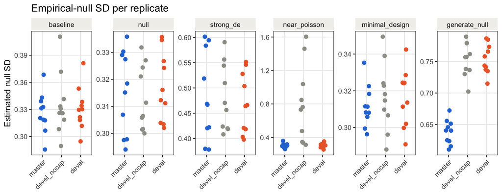

```r
plot_df <- run_df[run_df$version %in% c("master", "devel_nocap", "devel"), ]
plot_df$regime <- factor(plot_df$regime, levels = regime_levels)
plot_df$version <- factor(plot_df$version,
                          levels = c("master", "devel_nocap", "devel"))
plot1 <- ggplot2::ggplot(plot_df, ggplot2::aes(x = version, y = null_sd))
plot1 <- plot1 + ggplot2::geom_point(ggplot2::aes(colour = version),
                                     position = ggplot2::position_jitter(width = 0.15,
                                                                         height = 0,
                                                                         seed = 1),
                                     size = 2)
plot1 <- plot1 + ggplot2::facet_wrap(~ regime, nrow = 1, scales = "free_y")
plot1 <- plot1 + ggplot2::scale_colour_manual(values = version_col_vec,
                                              guide = "none")
plot1 <- plot1 + ggplot2::theme(axis.text.x = ggplot2::element_text(angle = 45,
                                                                    hjust = 1))
plot1 <- plot1 + ggplot2::labs(x = NULL, y = "Estimated null SD",
                               title = "Empirical-null SD per replicate")
plot(plot1)
```

`locfdr` converges more often under the cap than without it. The fallback to the truncated MLE is now mostly in `strong_de`, where the DE genes’ large statistics distort the spline fit. `devel` warns when it falls back; `master` may have fallen back as often, but had no way to report it. In `near_poisson` the uncapped arm’s null SD was more than twice master’s, and the cap brings it back.

# 7 Corner cases

Each row below perturbs one small cohort (10 individuals × 30 cells, 100 genes, 10 DE) and runs the full pipeline. “silent” means the pipeline finished without warnings.

```r
case_vec <- unique(corner_df$case)
corner_wide_df <- do.call(rbind, lapply(case_vec, function(cs){
  m <- corner_df[corner_df$case == cs & corner_df$version == "master", ]
  d <- corner_df[corner_df$case == cs & corner_df$version == "devel", ]
  .describe <- function(x){
    txt <- x$outcome
    if(x$outcome == "error") txt <- paste0("**error** in ", x$error)
    if(x$outcome == "warning") txt <- paste0("warning: ", x$warnings)
    if(!is.na(x$num_sig)) txt <- paste0(txt, " — ", x$num_sig, " genes at FDR < 0.05")
    if(!is.na(x$metric_value)) txt <- paste0(txt, "; ", x$metric_name, " = ",
                                             signif(x$metric_value, 3))
    substr(txt, 1, 330)
  }
  data.frame(Case = paste0("`", cs, "`: ", d$description),
             master = .describe(m),
             devel = .describe(d))
}))
knitr::kable(corner_wide_df,
             caption = "Behavior of each version on the perturbed cohorts. Messages truncated.")
```

Behavior of each version on the perturbed cohorts. Messages truncated.

| Case | master | devel |
| --- | --- | --- |
| `reference`: Unperturbed cohort (reference) | silent — 10 genes at FDR < 0.05 | silent — 10 genes at FDR < 0.05 |
| `determinism`: Same data, fitted after set.seed(1) and after set.seed(2) | silent — 10 genes at FDR < 0.05; max \|diff\| in Welch statistic between the two fits = 4.4e-12 | silent — 10 genes at FDR < 0.05; max \|diff\| in Welch statistic between the two fits = 0 |
| `sparse_input`: Same counts as a dgCMatrix | silent — 10 genes at FDR < 0.05; max \|diff\| in Welch statistic vs dense reference = 2.06e-11 | silent — 10 genes at FDR < 0.05; max \|diff\| in Welch statistic vs dense reference = 0 |
| `sparse_na`: One NA among the nonzero entries of a dgCMatrix | **error** in initialize_esvd: missing value where TRUE/FALSE needed | **error** in initialize_esvd: `covariates` contains NA or non-finite entries |
| `all_zero_gene`: Two genes are all-zero | warning: from glmnet C++ code (error code -1); Convergence for 1th lambda value not reached after maxit=100000 iterations; solutions for larger lambdas returned \|\| an empty model has been returned; … | **error** in initialize_esvd: 2 gene(s) are all zero (gene3, gene50); remove them before initialization, or run `eSVD_helper`, which removes them and records the removal in `gene_status` |
| `collinear_covariate`: A covariate column duplicated (Age twice) | **error** in opt_esvd (first): missing value where TRUE/FALSE needed | **error** in initialize_esvd: `covariates` is rank deficient (rank 5 for 6 columns): `Age_copy` can be written as a combination of the other columns. Remove one variable from each collinear set. Inclu… |
| `confounded_design`: Sex identical to case-control status | **error** in opt_esvd (first): missing value where TRUE/FALSE needed | **error** in initialize_esvd: `covariates` is rank deficient (rank 4 for 5 columns): `Sex_M` can be written as a combination of the other columns. Remove one variable from each collinear set. Includin… |
| `few_genes`: Only 30 genes | silent — 30 genes at FDR < 0.05 | warning: locfdr could not estimate the empirical null; using the `truncated_mle` estimator instead (null_mean = -0.1409, null_sd = 1.174). This usually means too few genes for locfdr’s spline fit — 0 … |
| `extreme_de`: 5 genes up-regulated by exp(4), nearly Poisson | silent — 5 genes at FDR < 0.05; largest Gaussian statistic = 5.04 | warning: locfdr could not estimate the empirical null; using the `truncated_mle` estimator instead (null_mean = -1.993, null_sd = 0.4051). This usually means too few genes for locfdr’s spline fit — 5 … |
| `one_case_individual`: The case arm has a single individual | **error** in compute_pvalue: missing values and NaN’s not allowed if ‘na.rm’ is FALSE | **error** in compute_test_statistic: each arm needs at least 2 individuals to form a two-sample test; found 1 case and 5 control. With one individual in an arm the Welch degrees of freedom are 0 and e… |
| `two_cell_individual`: One control individual has only 2 cells | silent — 10 genes at FDR < 0.05 | **error** in compute_test_statistic: individual(s) indiv1 (2 cells) have fewer than 3 cells. Remove them upstream (see `eSVD_helper`), or pass `min_cells_per_individual = 0` to proceed anyway |
| `individual_in_both_arms`: Half of one individual’s cells labelled case, half control | **error** in compute_test_statistic: length(intersect(control_individuals, case_individuals)) == 0 is not TRUE | **error** in compute_test_statistic: length(intersect(control_individuals, case_individuals)) == 0 is not TRUE |

Reading the table:

- **Fixed, and clearly better.**
  - `collinear_covariate` and `confounded_design` (Sex identical to case-control status) used to fail two stages later with `missing value where TRUE/FALSE needed` from `opt_esvd()`. Now they stop in `initialize_esvd()`, which names the redundant column.
  - `all_zero_gene` used to finish with glmnet convergence warnings and fit the zero genes anyway. Now it is refused by name and pointed at `eSVD_helper()`.
  - `one_case_individual` used to die in `compute_pvalue()` on `NaN`s. Now it stops in `compute_test_statistic()` with an explanation.
  - `two_cell_individual` used to run silently. Now it is refused, and can be overridden with `min_cells_per_individual = 0`.
- **`few_genes` is the most striking row.** With 30 genes, `master` declared **every gene significant**, silently: its unconstrained fallback estimator gave a degenerate empirical null. `devel` calls nothing significant. Under 1.1.0, `locfdr` converged on this cohort; under the cap it does not, and `devel` falls back to the truncated MLE and says so in a warning. The answer is the same either way.
- **The reference cohort** finds 10 genes at FDR < 0.05 under `devel`, as under `master`. Under 1.1.0 it found 13, which included false discoveries.
- **Unchanged.** `individual_in_both_arms` is refused by the same `stopifnot()` in both versions. The friendlier check lives in `eSVD()`, which these scripts do not call.
- **`determinism`**: `devel` is bit-identical across two fits after different `set.seed()` calls. `sparse_input` agrees with dense input in both versions.
- **`sparse_na` shows a gap between `NEWS.md` and behavior.**
  - `NEWS` says `initialize_esvd()` now zeroes `NA` counts in sparse matrices, but the pipeline never gets that far.
  - `format_covariates()` computes `Log_UMI = log(rowSums(dat))`, which is `NA` for that cell, and `initialize_esvd()` then stops on the covariates.
  - The error is clearer than `master`’s (`covariates` contains NA, against `missing value where TRUE/FALSE needed`). But it names the covariates rather than the count that caused them.
  - The zeroing only helps a caller who builds the covariates some other way.
- **`extreme_de`** (five genes up by $e^4$ on nearly Poisson genes): both versions find the five genes, and neither overflowed at this size. `devel` warns because `locfdr` falls back.

# 8 New since 1.1.0: a standard error for the log2 fold change

`master` has no counterpart. Below, the interval `logFC ± 2 SE` is checked against the true log2 fold change. For `devel` it is split by `nuisance_status`, and for `devel_nocap` by whether the rate diverged.

```r
.cover <- function(x, idx){
  if(!any(idx)) return(NA)
  mean(abs(x$logFC[idx] - x$truth_log2fc[idx]) <= 2 * x$logFC_se[idx])
}
se_df <- do.call(rbind, lapply(regime_levels, function(r){
  x <- devel_df[devel_df$regime == r, ]
  y <- nocap_df[nocap_df$regime == r, ]
  data.frame(regime = r,
             cover_estimated = .cover(x, x$nuisance_status == "estimated"),
             cover_capped = .cover(x, x$nuisance_status == "capped"),
             cover_boundary = .cover(x, x$nuisance_status == "boundary"),
             cover_nocap_diverged = .cover(y, y$nuisance > 1e4),
             median_se = stats::median(x$logFC_se))
}))
knitr::kable(se_df, digits = 3,
             col.names = c("Regime", "devel: estimated", "devel: capped",
                           "devel: boundary", "devel_nocap: rate > 1e4",
                           "devel: median SE"),
             caption = "Coverage of ±2 SE, all genes and replicates.")
```

Coverage of ±2 SE, all genes and replicates.

| Regime | devel: estimated | devel: capped | devel: boundary | devel_nocap: rate > 1e4 | devel: median SE |
| --- | --- | --- | --- | --- | --- |
| baseline | 0.999 | 0.991 | 1.000 | 0.412 | 0.366 |
| null | 0.999 | 0.997 | 1.000 | 0.474 | 0.370 |
| strong_de | 0.853 | 0.723 | 0.786 | 0.000 | 0.379 |
| near_poisson | 1.000 | 0.999 | 0.999 | 0.415 | 0.371 |
| minimal_design | 1.000 | 1.000 | 1.000 | 0.455 | 0.366 |
| generate_null | 1.000 | 0.990 | 1.000 | 0.080 | 0.495 |

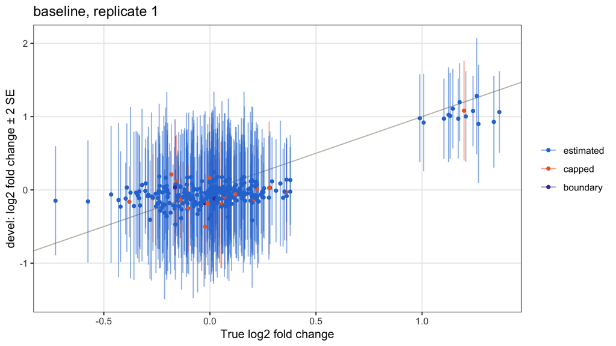

```r
plot_df <- devel_df[devel_df$regime == "baseline" & devel_df$rep == 1, ]
plot_df$nuisance_status <- factor(plot_df$nuisance_status,
                                  levels = names(nuisance_status_col_vec))
plot1 <- ggplot2::ggplot(plot_df, ggplot2::aes(x = truth_log2fc, y = logFC))
plot1 <- plot1 + ggplot2::geom_abline(slope = 1, intercept = 0,
                                      colour = "#c3c2b7", linewidth = 0.5)
plot1 <- plot1 + ggplot2::geom_errorbar(ggplot2::aes(ymin = logFC - 2 * logFC_se,
                                                     ymax = logFC + 2 * logFC_se,
                                                     colour = nuisance_status),
                                        width = 0, alpha = 0.5)
plot1 <- plot1 + ggplot2::geom_point(ggplot2::aes(colour = nuisance_status),
                                     size = 1.2)
plot1 <- plot1 + ggplot2::scale_colour_manual(values = nuisance_status_col_vec,
                                              name = NULL, drop = FALSE)
plot1 <- plot1 + ggplot2::labs(x = "True log2 fold change",
                               y = "devel: log2 fold change ± 2 SE",
                               title = "baseline, replicate 1")
plot(plot1)
```

**Under the cap the SE covers the truth at or above the nominal rate for genes of every status, in five of the six regimes.** It is conservative, because the within-individual term dominates. Without the cap, genes whose rate diverged had coverage well below nominal: their interval collapsed with the posterior variance. This answers, in simulation, the part of Q-LFC-1 that asked whether the cap repairs the SE.

The exception is `strong_de` (coverage about 0.85 for estimated genes, and lower for capped ones), with or without the cap. There, the ±3 effects move each case cell’s total count, so the `Log_UMI` depth adjustment shifts every gene’s fold change. That is a bias, which an SE cannot absorb.

# 9 Runtime

```r
runtime_df <- stats::aggregate(seconds ~ regime + version, data = run_df,
                               FUN = stats::median)
runtime_wide_df <- stats::reshape(runtime_df, idvar = "regime",
                                  timevar = "version", direction = "wide")
colnames(runtime_wide_df) <- sub("^seconds\\.", "", colnames(runtime_wide_df))
knitr::kable(runtime_wide_df, digits = 2,
             caption = "Median seconds per fit (600 cells × 300 genes).")
```

Median seconds per fit (600 cells × 300 genes).

| regime | devel | devel_nocap | devel_swap | master |
| --- | --- | --- | --- | --- |
| baseline | 2.20 | 2.20 | 2.20 | 1.67 |
| generate_null | 4.44 | 4.45 | 4.39 | 3.91 |
| minimal_design | 2.24 | 2.23 | 2.15 | 1.53 |
| near_poisson | 2.33 | 2.36 | 2.23 | 1.58 |
| null | 2.12 | 2.13 | 2.08 | 1.55 |
| strong_de | 2.17 | 2.19 | 2.17 | 1.65 |

`devel` is about a third slower than `master` on these small fits (about 0.6 s per fit). The cap itself costs nothing measurable (`devel` against `devel_nocap`). The rest has not been profiled.

# 10 Verdict

- **On the estimate researchers report first, the fold change, nothing changed.**
- **On the test, `devel` 1.2.0 is calibrated as `master` was, and its nuisance rate means something.**
  - `master` was calibrated by accident, through a bound at the largest library size that held nearly every gene.
  - 1.1.0 removed that bound and paid for it with false discoveries: 2.7 per 300 null genes under the null, and 63 in `near_poisson`.
  - 1.2.0 bounds the rate deliberately at 10 times the median library size. False discoveries return to master’s level, within noise, while about nine genes in ten keep their own estimate and the estimates track the truth (Spearman about 0.6 against about 0).
  - The ablation still attributes every difference in the statistics to the nuisance rate.
- **The cost** is a small loss of power on the `generate_null()` cohorts (0.7 of 10 DE genes per data set), and, at most, a few tenths of a false discovery per data set in the ordinary regimes, which the ten replicates cannot resolve.
- **Everything else in `NEWS.md` behaves as a corner-case fix**, and in those corners `devel` is clearly better: clear, early errors instead of deep crashes, and no silent “everything is significant” on small gene sets.

# 11 What we glossed over

- **Only simulated data, and mostly data from the eSVD model itself.**
  - The one outside generator (`generate_null()`) is also where `devel` loses a little power.
  - The default `cap_multiplier = 10` was chosen on simulations like these (`../OVERDISPERSION_BRAINSTORM.md`, section 3.3), so they are not a held-out test of it.
  - One real data set is the open check (Idea 11 of the brainstorm).
- **300 genes, 20 individuals, 30 cells per individual.** Chosen to fit the 30-minute budget. The false-discovery counts scale with the number of genes; the rates are what to compare. With ten replicates the SE of a per-data-set count is about 0.5.
- **The median library size is between 0.8 and 2.5 in every regime**, because the fit’s library includes the gene intercept. With `bool_library_includes_interept = FALSE` it would be in the thousands. That is where 1.2.0’s rule that a boundary gene goes to the cap itself (and not to the optimizer’s stopping value) matters, and it was not exercised here.
- **`eSVD()` itself was not run**, because it needs a Seurat object. The scripts call its steps in the same order and with its defaults, except `k = 3` and `max_iter = 50`. So `compute_test_per_gene()` (the `bool_diet = TRUE` path), `recompute_pvalue()` and the diagnostic plots were not compared here; the package’s tests cover them.
- **`master` is not bit-reproducible across runs on `generate_null()`.** Between the first edition of this report and this one, `master`’s Welch statistics on those cohorts moved by up to 0.006 on identical data, while `devel`’s did not move. This is the random SVD start that `devel` fixed, and it is why the ablation agrees to 0.006 rather than to every digit there.
- **The rescaling by `bool_stabilize_underdispersion`** divides every rate by their geometric mean when that mean is above 1. It is on in every arm. Diverged genes inflated that mean under 1.1.0, and the cap bounds it. Its separate contribution was not isolated.

# 12 References

- Lin, K. Z., Qiu, Y., and Roeder, K. (2024). eSVD-DE: cohort-wide differential expression in single-cell RNA-seq data using exponential-family embeddings. *BMC Bioinformatics* 25:113. [doi:10.1186/s12859-024-05724-7](https://doi.org/10.1186/s12859-024-05724-7)
- `NEWS.md` of this repository, sections 1.2.0, 1.1.0 and 1.0.2.
- `../OVERDISPERSION_BRAINSTORM.md` and `../overdispersion_brainstorm/overdispersion_cap_claude.html`: why the cap, and why 10.